# TCBD Results - Draft V2

Ciara Hovis, CSIS Lab, Michigan State University

14 October 2020

# 1. Summary

Synthesis of results for telacoupling/biodiversity systematic review. It consists of response summaries and visualizations of the accepted papers.

# 2. R Setup

The script presented here was done using R (version 4.0.2; R Core Team 2020) and its packages.

Load libraries, directories, and custom functions from source file.

# 3. Load data

```r
# surveys
  ab_screen <- read.csv(paste0(dat.dir, 'absScreening\\AbsScreen1_Merge.csv'))
  ab_maybes <- read.csv(paste0(dat.dir, 'absScreening\\AbsScreen2_maybes_to_keep.csv'))
  ab_yeses <- read.csv(paste0(dat.dir,  'absScreening\\final_sample_for_coding.csv'))
  assignments <- read.csv(paste0(dat.dir,'absScreening\\Coding_MergeAssign_R1.csv'))

  survey1 <- read.csv(paste0(dat.dir,'survey1_cleaned.csv'))
  s2 <- read.csv(paste0(dat.dir,'survey2_cleaned.csv'))
  survey3 <- read.csv(paste0(dat.dir,'survey3_cleaned.csv'))
  s23 <- read.csv(paste0(dat.dir,'s23.csv'))

  taxEff<- read.csv(paste0(dat.dir,'tax_eff.csv'))

# factor format
  s23$maj_eff<-factor(s23$maj_eff, c("Beneficial","Harmful","Changed", "Mixed","Not significant or unclear"))
  s23_maj <- s23[!duplicated(s23$paper_id),]

  taxEff$maj_eff_taxa<-factor(taxEff$maj_eff_taxa, c("Beneficial","Harmful","Changed", "Mixed","Not significant or unclear"))
  taxEff_maj <- taxEff[!duplicated(taxEff$tax_ID),]
```

# 4. Survey 1 & 2 Results

## 4.1 Sample Results

Accepted/rejected published papers over time

Total number of papers at the coding stage = 591

```r
# get total numbers but also ensure both values here match
  nrow(survey1)
  length(unique(survey1$paper_id))
```

```
## [1] 591
## [1] 591
```

Number of accepted and rejected papers.

Accepted = 131 (22%) , Rejected = 460 (78%)

```r
# get summary
  ddply(survey1, .(status), summarize,
        # total count of entries
        count=length(status))
sum(survey1$status == 'accept')/nrow(survey1)
sum(survey1$status == 'reject')/nrow(survey1)
```

| status | count |
| --- | --- |
| accept | 131 |
| reject | 460 |

```
## [1] 0.2216582
## [1] 0.7783418
```

Visualizing accepted papers over time, including the ones from the abstract screening process.

```r
# all abstract screened papers (n=7306)
  ab_screen <- ab_screen[!ab_screen$PY==2020,] #remove 2020 studies
  ab_all <- ab_screen[!duplicated(ab_screen$TITLE),];nrow(ab_all)

# remove the papers accepted in screening from the abstract screening list (n=6665)
  ab_reject <- anti_join(ab_all,ab_maybes,by=c("TITLE"))
  ab_reject <- anti_join(ab_reject,ab_yeses,by=c("TITLE"))
  ab_reject <- ab_reject[!duplicated(ab_reject$TITLE,ab_reject$PY),];nrow(ab_reject)

# all papers that were accepted from abstract screening (n=641)
  ab_accept <- ab_yeses[!duplicated(ab_yeses$TITLE),]


# accepted papers from the assignment list for full review (n=595)
  papers_reviewed <- assignments[!duplicated(assignments$TITLE),]

# papers with PDF not available or rejected because of language (n=46)
  paper_unavail <- anti_join(ab_accept,papers_reviewed,by=c("TITLE"))
  paper_unavail <- paper_unavail[!duplicated(paper_unavail$TITLE),]

# rejected papers or not yet reviewed (n=460)

  keep <-  subset(survey1, status=='accept')
  reject <- anti_join(survey1,keep)

  papers_rejected <- anti_join(papers_reviewed,keep,by=c("STUDY_ID.1"="paper_id"))
  papers_rejected <- papers_rejected[!duplicated(papers_rejected$TITLE),]
```

```
## [1] 7306
## [1] 6665
```

```r
# show numbers:
  paste('original number of papers in WOS search:',nrow(ab_screen))
  paste('number of duplicates in WOS search:',nrow(ab_screen)-nrow(ab_all))
  paste('number of abstracts screened:',nrow(ab_all))
  paste('number of accepted abstracts:',nrow(ab_accept))
  paste('number of rejected abstracts:',nrow(ab_reject))
  paste('number of accepted papers unavailable or non-English:',
        nrow(paper_unavail))
  paste('number of papers available for full review:',
        nrow(papers_reviewed))
  paste('number of full papers accepted for synthesis:',
        nrow(keep))
  paste('number of full papers rejected from synthesis:',nrow(reject))
  paste('number of full papers not yet reviewed for synthesis:',
        nrow(papers_rejected)-nrow(reject)-5)

# num of full papers not yet reviewed is -1, idk why. Maybe due to common papers? The check below is True so I'm not worried.


# test if they add up correctly
  paste('COUNT TESTS:')
  paste('total full papers:',
        nrow(papers_reviewed) == nrow(ab_accept) - nrow(paper_unavail))
  paste('total abstract screen:',
        nrow(ab_all) == nrow(ab_reject) + nrow(ab_accept))
```

```
## [1] "original number of papers in WOS search: 7318"
## [1] "number of duplicates in WOS search: 12"
## [1] "number of abstracts screened: 7306"
## [1] "number of accepted abstracts: 641"
## [1] "number of rejected abstracts: 6665"
## [1] "number of accepted papers unavailable or non-English: 46"
## [1] "number of papers available for full review: 595"
## [1] "number of full papers accepted for synthesis: 131"
## [1] "number of full papers rejected from synthesis: 460"
## [1] "number of full papers not yet reviewed for synthesis: -1"
## [1] "COUNT TESTS:"
## [1] "total full papers: TRUE"
## [1] "total abstract screen: TRUE"
```

Next, simplify columns and combine for three tiers in the plot.

```r
# select columns
  # papers found in WOS but don't meet criteria
    reject_abstract_level <- subset(ab_reject,select=c("STUDY_ID","PY"))
  # WOS papers that meet criteria but don't directly look at coupling effects on biodiv
    reject_paper_level <- subset(papers_rejected,select=c("STUDY_ID.1","PY"))
    reject_paper_level2 <- subset(paper_unavail,select=c("STUDY_ID","PY"))
  # papers that do look at coupling effects on biodiv
    accept_paper_level <- subset(keep,select=c("paper_id","year_pub"))

# rename columns
  colnames(reject_abstract_level) <- c('paper_id','year_pub')
  colnames(reject_paper_level) <- c('paper_id','year_pub')
  colnames(reject_paper_level2) <- c('paper_id','year_pub')

# add columns
  #papers that discuss tc effects on biodiv in...
  reject_abstract_level$type <- 'search but not abstract'
  reject_paper_level$type <- 'abstract but not paper'
  reject_paper_level2$type <- 'abstract but not paper'
  accept_paper_level$type <- 'abstract and paper'

# rbind (should be 7307 rows)
  papers <- rbind(reject_abstract_level,reject_paper_level,
                  reject_paper_level2, # <-- NOT SURE IF UNAVAILABLE PAPERS BELONG HERE
                  accept_paper_level)

# check
  nrow(papers)
```

```
## [1] 7306
```

Plot image.

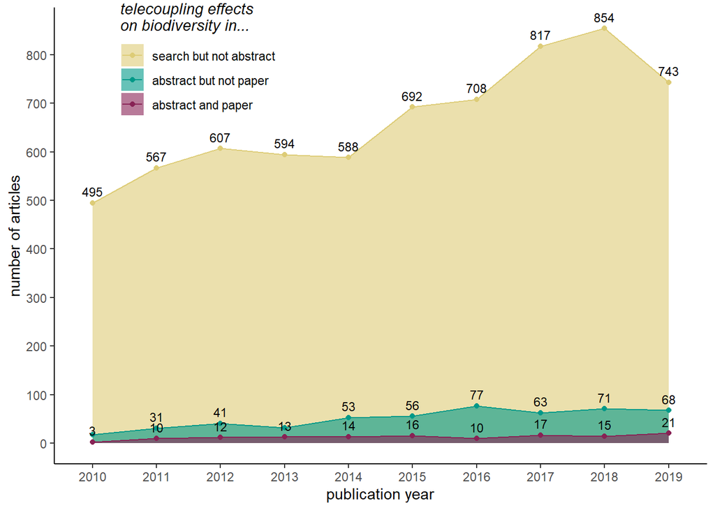

```r
# Get a count of records per year
  paper_ct <- ddply(papers, .(year_pub,type), summarize, count=length(year_pub))

# Change to factors
  paper_ct$year_pub <- as.factor(paper_ct$year_pub)
  paper_ct$type <- factor(paper_ct$type,
                        levels = c('search but not abstract',
                                   'abstract but not paper',
                                   'abstract and paper'))

  papers.fig <- ggplot(paper_ct, aes(x=year_pub, y=count)) +
                  geom_area(position="identity",
                            aes(y=count, fill = type, group = type), alpha=0.6) +
                  geom_point(aes(y =count, color = type, group = type))+
                  geom_line(aes(y =count, color = type, group = type))+
                  geom_text(aes(label=count),size=3,
                            position=position_dodge(.7),
                            vjust=-.7,
                            check_overlap=TRUE)+
                  scale_color_manual(
                  name=expression(italic("telecoupling effects\non biodiversity in...")),
                  values=paper_col)+
                  scale_fill_manual(
                  name=expression(italic("telecoupling effects\non biodiversity in...")),
                  values=paper_col)+
                  xlab("publication year")+
                  ylab("number of articles") + ylim(0,860)+
                  scale_y_continuous(breaks=seq(0,850,100)) +
                  theme_classic()+
                  theme(legend.position = c(0.22,0.87))

# show here
  papers.fig
```

Acceptance rate for abstract screening.

```r
# get total abstract acceptance rate
  sum(ab_all$INCLUDE=='YES')/nrow(ab_all)
```

```
## [1] 0.08007117
```

Acceptance rate for papers that were reviewed (**NOTE:** this includes the 5 common surveys).

```r
# get total paper acceptance rate
  sum(survey1$status=='accept')/nrow(survey1)
```

```
## [1] 0.2216582
```

Acceptance rate per person (**NOTE:** this excludes the 5 common surveys per person, but has a rate for it on its own as “all”).

```r
# get summary
  acr <- ddply(survey1, .(coder_id), summarize,
              # total count of entries
              count=length(coder_id),
              accept=sum(status=='accept'),
              reject=sum(status=='reject'),
              # percent acceptance
              accept_rate=sum(status=='accept')/length(coder_id))
  acr
```

| coder_id | count | accept | reject | accept_rate |
| --- | --- | --- | --- | --- |
| A_Herzberger | 63 | 20 | 43 | 0.3174603 |
| A_Torres | 51 | 7 | 44 | 0.1372549 |
| all | 5 | 4 | 1 | 0.8000000 |
| C_Hovis | 92 | 19 | 73 | 0.2065217 |
| E_Dean | 43 | 7 | 36 | 0.1627907 |
| E_Xing | 43 | 9 | 34 | 0.2093023 |
| K_Kapsar | 52 | 11 | 41 | 0.2115385 |
| M_Lei | 43 | 15 | 28 | 0.3488372 |
| MG_Chung | 43 | 5 | 38 | 0.1162791 |
| X_Wu | 67 | 18 | 49 | 0.2686567 |

[output cut: 3 more lines]

Average per-person acceptance rates

```r
# mean per-person acceptance rate
  mean(acr$accept_rate)
```

```
## [1] 0.2392594
```

Unique study ids for survey 2 and 3

```r
length(unique(s2$paper_id))
length(unique(survey3$paper_id))
length(unique(s23$paper_id))

`%notin%` <- Negate(`%in%`)

halp <- s2[which(unique(s2$paper_id) %notin% unique(survey3$paper_id)),]
```

```
## [1] 131
## [1] 131
## [1] 131
```

## 4.2 General Results

Proportion of effects at article and metric level

```r
# Table of maj_eff
table(taxEff_maj$maj_eff_taxa)
prop.table(table(taxEff_maj$maj_eff_tax))

# Table of sig_eff
table(s23$sig_effect)
prop.table(table(s23$sig_effect))
nrow(s23)
```

```
##
##                 Beneficial                    Harmful
##                         16                         67
##                    Changed                      Mixed
##                         11                          9
## Not significant or unclear
##                         33
##
##                 Beneficial                    Harmful
##                 0.11764706                 0.49264706
##                    Changed                      Mixed
##                 0.08088235                 0.06617647
## Not significant or unclear
##                 0.24264706
##
##                 Beneficial                    Changed
##                         82                        101
##                    Harmful Not significant or unclear
##                        225                        359
##
##                 Beneficial                    Changed
##                  0.1069100                  0.1316819
##                    Harmful Not significant or unclear
##                  0.2933507                  0.4680574
## [1] 767
```

Habitat Frequency (study level, n= 131)

```r
habitat.study <- count(s23_maj, 'hab')
print(habitat.study)
prop.table(table(s23_maj$hab))
```

```
##                          hab freq
## 1                 Freshwater   22
## 2          Freshwater;Marine    1
## 3                     Marine   25
## 4 Not specified/Global study    2
## 5                Terrestrial   75
## 6     Terrestrial;Freshwater    4
## 7         Terrestrial;Marine    2
##
##                 Freshwater          Freshwater;Marine
##                0.167938931                0.007633588
##                     Marine Not specified/Global study
##                0.190839695                0.015267176
##                Terrestrial     Terrestrial;Freshwater
##                0.572519084                0.030534351
##         Terrestrial;Marine
##                0.015267176
```

Taxa Frequency (study level, n=131)

```r
desired_length <- 8
empty_list <- vector(mode = "list", length = desired_length)

taxa <- (taxEff_maj$taxa)
table(taxa)
taxa.list <- c('Mammals', 'Plants', 'Reptiles', 'Amphibians', 'Birds', 'Fish', 'Invertebrates', 'Multiple')
taxa.count <- empty_list

for (i in 1:length(taxa.list)) {

  taxa.count[i] <- sum(str_count(taxa, taxa.list[i]))
    }

taxa.count <- as.data.frame(cbind(taxa.list,taxa.count))
taxa.count
taxa.count$perc <- (as.numeric(taxa.count$taxa.count)/131) * 100
taxa.count <- taxa.count[order(-taxa.count$perc),]
taxa.count

mult <- as.data.frame((table(taxEff_maj$paper_id)))
mult <- mult[which(mult$Freq != 1),]
num.mult <- sum(nrow(mult),(taxa.count[2,8]))

# Others? Not a big deal since taxa is clarified in survey 3.Not a big deal.

othTaxa <- s2[which(s2$taxa == 'Other'),]
```

```
## taxa
##          Amphibians               Birds                Fish       Invertebrates
##                   1                  37                  15                  29
##             Mammals            Multiple Plants/Trees/Shrubs            Reptiles
##                  15                   5                  30                   4
```

| taxa.list | taxa.count |
| --- | --- |

|  | taxa.list | taxa.count | perc |
| --- | --- | --- | --- |
| 5 |  |  | 28.2442748 |
| 2 |  |  | 22.9007634 |
| 7 |  |  | 22.1374046 |
| 1 |  |  | 11.4503817 |
| 6 |  |  | 11.4503817 |
| 8 |  |  | 3.8167939 |
| 3 |  |  | 3.0534351 |
| 4 |  |  | 0.7633588 |

Flow frequency (study level, n=131)

```r
desired_length <- 9
empty_list <- vector(mode = 'list', length = desired_length)

tc <- s2$tele_cat
tc.list <-c("Energy Transfer","Investment","Knowledge Transfer",
                                 "Migration (human)",
                                 "Species Dispersal","Tourism","Trade","Waste Transfer","Water Transfer")
tc.count <- empty_list

for (i in 1:length(tc.list)) {

  tc.count[i] <- sum(str_count(tc, tc.list[i]))
    }

tc.count <- as.data.frame(cbind(tc.list,tc.count))
tc.count


# Can't get loop to count the migration values for some reason, manual input code below
# Migration (human) n=4     # Migration (non-human) n=0
tc.table <- table(s2$tele_cat)
tc.table
tc.count[4,2] <- tc.table[5] + tc.table[13]      # Migration (human) n=4

tc.count$perc <- (as.numeric(tc.count$tc.count)/131) * 100
tc.count <- tc.count[order(-tc.count$perc),]
tc.count


#gather(tc.count)

multiple <- str_count(tc, ';')
multiple <- multiple != 0
multiple <- table(multiple) ["TRUE"]
multiple/nrow(s2)
```

| tc.list | tc.count |
| --- | --- |

```
##
##                      Energy Transfer                           Investment
##                                    7                                    4
##                   Knowledge Transfer        Knowledge Transfer;Investment
##                                    6                                    3
##                    Migration (human)                    Species Dispersal
##                                    3                                   13
## Species Dispersal;Knowledge Transfer                              Tourism
##                                    1                                   54
##                   Tourism;Investment                                Trade
##                                    1                                   25
##                Trade;Energy Transfer             Trade;Knowledge Transfer
##                                    1                                    2
##              Trade;Migration (human)              Trade;Species Dispersal
##                                    1                                    3
##                        Trade;Tourism     Trade;Tourism;Knowledge Transfer
##                                    1                                    1
##                       Waste Transfer                       Water Transfer
##                                    1                                    2
##       Water Transfer;Energy Transfer        Water Transfer;Waste Transfer
##                                    1                                    1
```

|  | tc.list | tc.count | perc |
| --- | --- | --- | --- |
| 6 |  |  | 43.511450 |
| 7 |  |  | 25.954198 |
| 5 |  |  | 12.977099 |
| 3 |  |  | 9.923664 |
| 1 |  |  | 6.870229 |
| 2 |  |  | 6.106870 |
| 4 |  |  | 3.053435 |
| 9 |  |  | 3.053435 |
| 8 |  |  | 1.526718 |

```
##      TRUE
## 0.1221374
```

Number of metrics reported by each paper

```r
# get summary
  ddply(survey3, .(paper_id), summarize,
        # total count of entries
        num_entries=length(entry_id),
        perc_dataset=length(entry_id)/nrow(survey3),
        num_taxa=length(unique(taxa))) %>%
    arrange(desc(perc_dataset))

num.metric <- count(survey3$paper_id)
mult.metric <- num.metric[num.metric$freq > 1,]

nrow(mult.metric)/131

range(num.metric$freq)
sum(num.metric$freq)
```

| paper_id | num_entries | perc_dataset | num_taxa |
| --- | --- | --- | --- |
| 84 | 162 | 0.211212516 | 1 |
| 4060 | 57 | 0.074315515 | 1 |
| 1551 | 27 | 0.035202086 | 1 |
| 1488 | 24 | 0.031290743 | 1 |
| 3772 | 22 | 0.028683181 | 1 |
| 6502 | 21 | 0.027379400 | 1 |
| 134 | 20 | 0.026075619 | 1 |
| 4155 | 20 | 0.026075619 | 1 |
| 4552 | 15 | 0.019556714 | 1 |
| 479 | 14 | 0.018252934 | 1 |

[output cut: 121 more lines]

```
## [1] 0.7022901
## [1]   1 162
## [1] 767
```

## 4.3 Biodiversity and Flow Categories by Country

Continent freq n=131

```r
cont <- s23_maj$bd_continents
table(cont)
desired_length <- 7
empty_list <- vector(mode = 'list', length = desired_length)

cont.list <-c("North America","South America","Africa","Europe","Oceania","Asia","Antarctica")
cont.count <- empty_list

for (i in 1:length(cont.list)) {

  cont.count[i] <- sum(str_count(cont, cont.list[i]))
    }

cont.count <- as.data.frame(cbind(cont.list,cont.count))
cont.count
cont.count$perc <- (as.numeric(cont.count$cont.count)/131) * 100
cont.count <- cont.count[order(-cont.count$perc),]
cont.count
```

```
## cont
##        Africa    Antarctica          Asia        Europe North America
##            10             1            25            30            22
##       Oceania South America
##            17            26
```

| cont.list | cont.count |
| --- | --- |

|  | cont.list | cont.count | perc |
| --- | --- | --- | --- |
| 4 |  |  | 22.9007634 |
| 2 |  |  | 19.8473282 |
| 6 |  |  | 19.0839695 |
| 1 |  |  | 16.7938931 |
| 5 |  |  | 12.9770992 |
| 3 |  |  | 7.6335878 |
| 7 |  |  | 0.7633588 |

Biodiversity country map

```r
shp <- ne_countries(scale = 50, returnclass = 'sf') %>% #st_as_sf() %>%
  select(name, iso_a3) %>% ## , economy, income_grp
  # filter(name != 'Antarctica') %>%
  # filter(name == 'France') %>%
  dplyr::mutate(
    iso_a3 = if_else(name == 'France', 'FRA', iso_a3),
    iso_a3 = if_else(name == 'Norway', 'NOR', iso_a3))
# plot(shp[1])

shp %>% filter(name == 'Norway')

### - Read in Data

df99 <- s23_maj

### - biodiv_countries
ctr_bio <- df99 %>%
  select(paper_id, biodiv_countries) %>%
  data.frame(., do.call(rbind, str_split(.$biodiv_countries,';'))) %>%
  gather(key = 'key', value = biodiv_countries, 3:ncol(.)) %>%
  dplyr::mutate(biodiv_countries = trimws(biodiv_countries)) %>%
  dplyr::distinct(paper_id, biodiv_countries, .keep_all = T) %>%
  filter(biodiv_countries != '') %>%
  arrange(paper_id) %>%
  group_by(biodiv_countries) %>%
  tally()%>%
  arrange(desc(n)) #%>%
# str(ctr_bio)

table(ctr_bio$biodiv_countries)

# install.packages("jsonlite", repos="https://cran.rstudio.com/")
library("jsonlite")
json_file <- 'https://datahub.io/JohnSnowLabs/country-and-continent-codes-list/datapackage.json'
json_data <- fromJSON(paste(readLines(json_file), collapse=""))
# get list of all resources:
print(json_data$resources$name)

# print all tabular data(if exists any) to 'data'
for(i in 1:length(json_data$resources$datahub$type)){
  if(json_data$resources$datahub$type[i]=='derived/csv'){
    path_to_file = json_data$resources$path[i]
    data <- read.csv(url(path_to_file))
    print(data)
  }
}

cont <- cbind(data$Continent_Name,data$Country_Name,data$Three_Letter_Country_Code)
cont <- as.data.frame(cont)

# Match continent and country name to biodiversity countries
names(cont)[1:3] <- c("continent","ctr_name","ctr_code")

ctr_bio$continent <- cont$continent[match(ctr_bio$biodiv_countries,cont$ctr_code)]  # add continent name
ctr_bio$ctr_name <- cont$ctr_name[match(ctr_bio$biodiv_countries,cont$ctr_code)]  # add country name
```

|  | name | iso_a3 | geometry |
| --- | --- | --- | --- |
| 1 | Norway | NOR |  |

```
##
## ALB ARG ATA AUS AUT BEL BEN BGR BHS BLR BOL BRA BTN BWA CAF CAN CHL CHN COL CRI
##   1   1   1   1   1   1   1   1   1   1   1   1   1   1   1   1   1   1   1   1
## CUB CYP CZE DEU DNK ECU ESP EST FIN FRA GBR GRC HRV HUN IDN IND IRL IRN ITA KOR
##   1   1   1   1   1   1   1   1   1   1   1   1   1   1   1   1   1   1   1   1
## LTU LUX LVA MAR MDV MEX MLT MNE MNG MWI MYS NAM NLD NPL NZL PER PHL POL PRT PRY
##   1   1   1   1   1   1   1   1   1   1   1   1   1   1   1   1   1   1   1   1
## PYF ROU RUS SLB SVK SVN SWE THA TZA UKR URY USA ZAF ZWE
##   1   1   1   1   1   1   1   1   1   1   1   1   1   1
## [1] "validation_report"
## [2] "country-and-continent-codes-list-csv_csv"
## [3] "country-and-continent-codes-list-csv_json"
## [4] "country-and-continent-codes-list_zip"
## [5] "country-and-continent-codes-list-csv"
##     Continent_Name Continent_Code
```

[output cut: 788 more lines]

# 5. Telecoupling Impact by Taxa

Note that n=136, some papers reported metrics for multiple taxa. Maj_eff was determined based on paper and taxa for these figures.

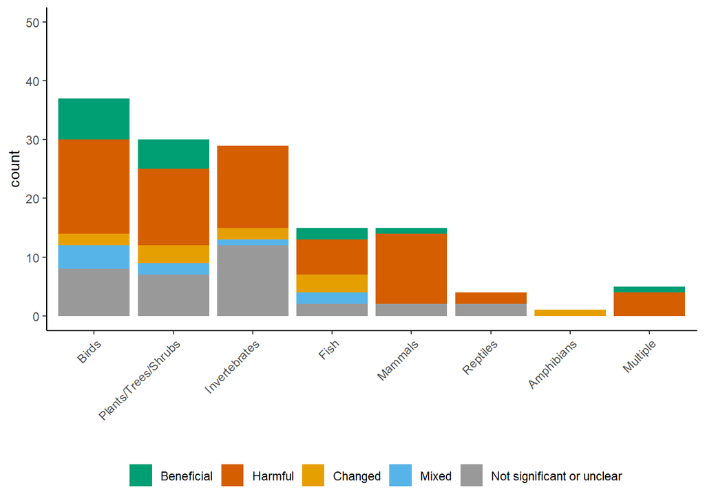

| Var1 | Freq | perc |
| --- | --- | --- |
| Beneficial | 16 | 11.764706 |
| Harmful | 67 | 49.264706 |
| Changed | 11 | 8.088235 |
| Mixed | 9 | 6.617647 |
| Not significant or unclear | 33 | 24.264706 |

```
## [1] "Birds"               "Plants/Trees/Shrubs" "Invertebrates"
## [4] "Fish"                "Mammals"             "Multiple"
## [7] "Reptiles"            "Amphibians"
```

```r
taxa_tab <- as.data.frame(table(taxEff_maj$maj_eff_taxa))
taxa_tab$perc <- (taxa_tab$Freq/sum(taxa_tab$Freq))*100
taxa_tab
# get summary
  a <- ddply(taxEff_maj, .(taxa, maj_eff_taxa), summarize,
          # total count of entries
          count=length(taxa)) %>%
          # percents of effects within totals per taxa
          group_by(taxa) %>%
            nest() %>%
             mutate(perc_per_taxa=map(data, function(x) x$count/sum(x$count))) %>%
              unnest(cols = c(data, perc_per_taxa))

# save as csv
#  write.csv(a, paste0(tab.dir,'survey3_summary_effects_by_taxa.csv'),row.names = TRUE)

  q <- table(taxEff_maj$taxa)
  q <- q[order(-(q))]
  taxa.sorted <- names(q);taxa.sorted
  taxa.sorted <- c(taxa.sorted,taxa.sorted[6])
  taxa.sorted <-taxa.sorted[-6]
  a$taxa <- factor(a$taxa,taxa.sorted)
  taxa.bar.data <- a
# Stack plot (count)
  taxa_bar <- ggplot(a, aes(fill=maj_eff_taxa, y=count, x=taxa)) +
                geom_bar(position="stack", stat="identity") +
                theme_classic() +
                theme(axis.text.x = element_text(angle = 45, hjust = 1)) +
                scale_fill_manual(values=majeff_col) +
                xlab("") +
                ylim(0,50) +
               theme(legend.position = "bottom",legend.justification='center',
                     legend.direction='horizontal',legend.title = element_blank())
taxa_bar
```

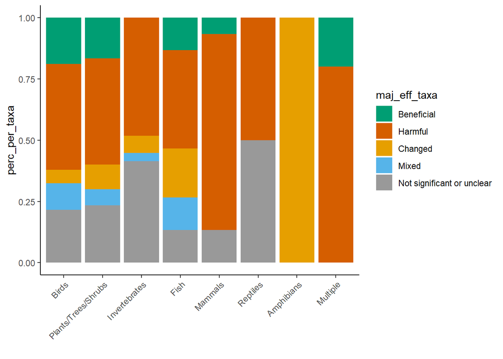

```r
# Stack plot (percentage)
  quick_plot <- ggplot(a, aes(fill=maj_eff_taxa, y=perc_per_taxa, x=taxa)) +
                geom_bar(position="stack", stat="identity") +
                theme_classic() +
                theme(axis.text.x = element_text(angle = 45, hjust = 1)) +
                scale_fill_manual(values=majeff_col) +
                xlab("")
quick_plot
```

# 7. Telecoupling Impact by Flow

Duplicate rows with multiple flow types. This means that effects and other results will be *duplicated* as well.

The reason for doing this is so that we can attribute biodiversity impacts to the specific flows that may have been studied together, and whose individual impacts cannot be decoupled.

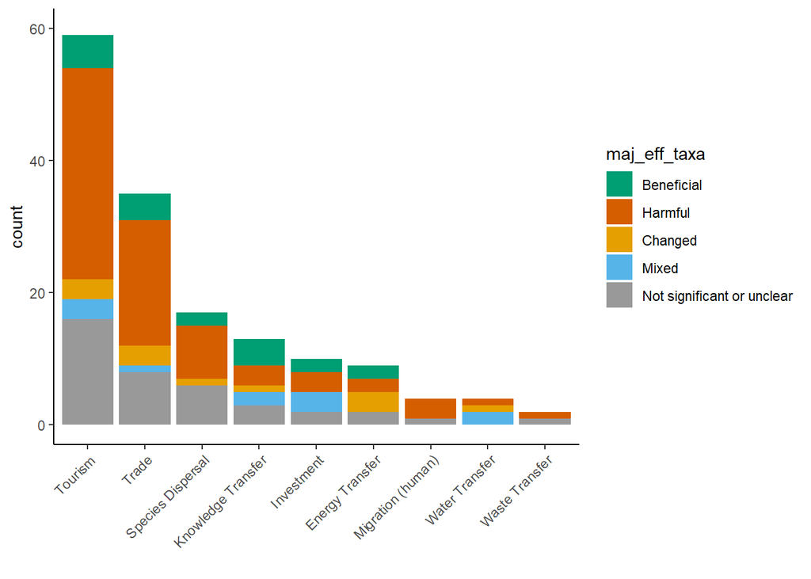

```
## [1] "Original number of rows: 136"
## [1] "Number of rows after separating multiple flows per paper: 153"
```

| Var1 | Freq | perc |
| --- | --- | --- |
| Beneficial | 19 | 12.418301 |
| Harmful | 72 | 47.058824 |
| Changed | 12 | 7.843137 |
| Mixed | 11 | 7.189542 |
| Not significant or unclear | 39 | 25.490196 |

```
## [1] "Tourism"            "Trade"              "Species Dispersal"
## [4] "Knowledge Transfer" "Investment"         "Energy Transfer"
## [7] "Migration (human)"  "Water Transfer"     "Waste Transfer"
```

```r
# set as character
taxEff_maj$tc <- as.character(taxEff_maj$tc)

# show original length of rows
  print(paste('Original number of rows:',nrow(taxEff_maj)))

# split multiple flows listed in a row into other new rows
  taxEff_maj_rep <- separate_rows(taxEff_maj, tc, sep=";", convert = TRUE)
  taxEff_maj_rep$tc <- as.factor(taxEff_maj_rep$tc)

# show new length of rows
  print(paste('Number of rows after separating multiple flows per paper:',nrow(taxEff_maj_rep)))

# show levels
#  summary(tcRep$tc)
tc_tab <- as.data.frame(table(taxEff_maj_rep$maj_eff_taxa))
tc_tab$perc <- (tc_tab$Freq/sum(tc_tab$Freq))*100
tc_tab


# get summary
  a <- ddply(taxEff_maj_rep, .(tc, maj_eff_taxa), summarize,
          # total count of entries
          count=length(tc)) %>%
          # percents of effects within totals per tc
          group_by(tc) %>%
            nest() %>%
             mutate(perc_per_tc=map(data, function(x) x$count/sum(x$count))) %>%
              unnest(cols = c(data, perc_per_tc))

  q <- table(taxEff_maj_rep$tc)
  q <- q[order(-(q))]
  tc.sorted <- names(q);tc.sorted
  a$tc <- factor(a$tc,tc.sorted)
  flow_bar_data <- a
# save as csv
#  write.csv(a, paste0(tab.dir,'survey3_summary_effects_by_flow.csv'),row.names = TRUE)

# Stack plot (count)
  flow_bar <- ggplot(a, aes(fill=maj_eff_taxa, y=count, x=tc)) +
                geom_bar(position="stack", stat="identity") +
                theme_classic() +
                theme(axis.text.x = element_text(angle = 45, hjust = 1)) +
                scale_fill_manual(values=majeff_col) +
                xlab("") +
                ylim(0,60)



# view
  flow_bar
```

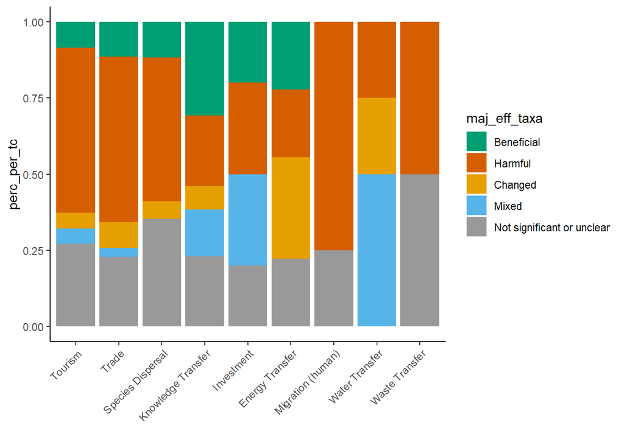

```r
# Stack plot (percent)
  quick_plot <- ggplot(a, aes(fill=maj_eff_taxa, y=perc_per_tc, x=tc)) +
                geom_bar(position="stack", stat="identity") +
                theme_classic() +
                theme(axis.text.x = element_text(angle = 45, hjust = 1)) +
                scale_fill_manual(values=majeff_col) +
                xlab("")

quick_plot
```

Side by side plot of taxa barchart and flow barchart

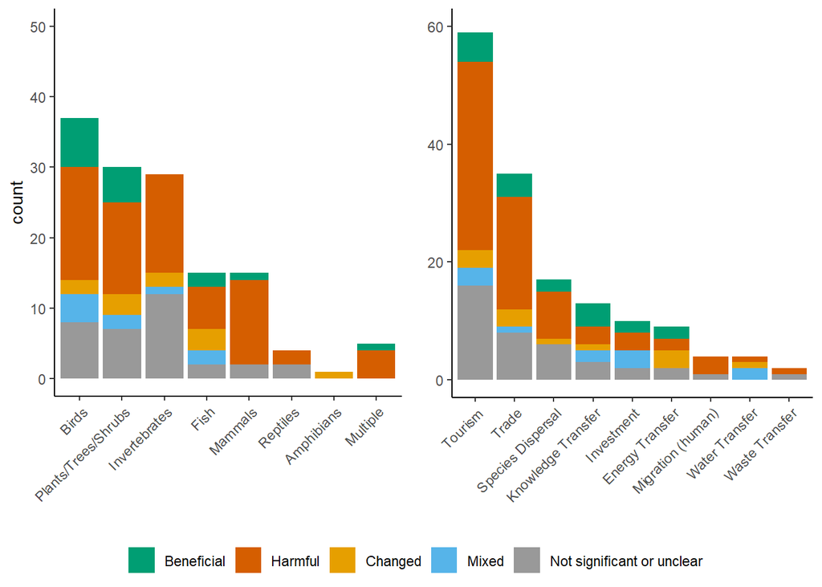

```r
taxa_bar2 <- taxa_bar + theme(legend.position = 'none')

flow_bar2 <- flow_bar + ylab(element_blank()) + theme(legend.position = 'none')



# theme(legend.position = "bottom",legend.justification='center',
# legend.direction='horizontal',legend.title = element_blank())

#extract legend
#https://github.com/hadley/ggplot2/wiki/Share-a-legend-between-two-ggplot2-graphs
g_legend<-function(a.gplot){
  tmp <- ggplot_gtable(ggplot_build(a.gplot))
  leg <- which(sapply(tmp$grobs, function(x) x$name) == "guide-box")
  legend <- tmp$grobs[[leg]]
  return(legend)}

mylegend<-g_legend(taxa_bar)

merge_bar <- grid.arrange(arrangeGrob(taxa_bar2,flow_bar2,nrow=1),mylegend, nrow=2,heights=c(10, 1))
```

```r
#merge_bar <- ggarrange(taxa_bar2, flow_bar2, mylegend,ncol=2, nrow=2,labels = c('a', 'b'))
#merge_bar
```

# 8. Telecoupling impacts by at the entry level

Replicate TC flows by entry

```r
# set as character
  s23$tc <- as.character(s23$tc)
  poo<-s23[is.na(s23$tc),]


# show original length of rows
  print(paste('Original number of rows:',nrow(s23)))

# split multiple flows listed in a row into other new rows
  tcRep <- separate_rows(s23, tc, sep=";", convert = TRUE)
  tcRep$tc <- as.factor(tcRep$tc)

# show new length of rows
  print(paste('Number of rows after separating multiple flows per paper:',nrow(tcRep)))

  tcRep_maj <- tcRep[!duplicated(tcRep$paper_id),]
```

```
## [1] "Original number of rows: 767"
## [1] "Number of rows after separating multiple flows per paper: 807"
```

## Impacts by metric

Convert to long format, where metric is indicated.

```r
# subset
  metrics <- subset(tcRep,
                    select=c('paper_id','entry_id',
                            'taxa','tc','sig_effect',
                            'biodiv_cat_1sp',
                            'biodiv_cat_multsp',
                            'biodiv_cat_habitat'))
# melt
  metrics_long <- melt(metrics, id.vars=c('paper_id','entry_id',
                            'taxa','tc','sig_effect'))

# remove NA fields
  metrics_long <- metrics_long[!is.na(metrics_long$value),]

# change colnames
  colnames(metrics_long)[6] <- 'metric_type'
  colnames(metrics_long)[7] <- 'metric'


# change levels
  levels(metrics_long$metric_type) <- c('Single species',
                                        'Multiple species',
                                        'Habitat')

  levels(as.factor(metrics_long$metric))

# remove parentheses
  metrics_long$metric <- gsub("\\s*\\([^\\)]+\\)", '',
                          as.character(metrics_long$metric))

# capitalize each word
  metrics_long$metric <- tools::toTitleCase(metrics_long$metric)

# adjust name
  metrics_long$metric <- gsub("With-in", 'Within',
                        as.character(metrics_long$metric))

# change levels, moving other to the end
  metrics_long$metric <- factor(metrics_long$metric,
                                c("Abundance/Density",
                                   "Amount",
                                   "Composition",
                                   "Detection",
                                   "Diversity Index",
                                   "Evenness",
                                   "Movement",
                                   "Occurrence",
                                   "Population Dynamics",
                                   "Quality",
                                   "Richness",
                                   "Within Species Diversity"
                                  ))

# check levels
  levels(as.factor(metrics_long$metric))

# get summary
  metric_flow <- ddply(metrics_long,
                       .(metric_type, metric, tc, sig_effect),
                       summarize,
                      # total count of entries
                        count=length(metric))

# save as csv
#  write.csv(metric_flow, paste0(tab.dir,'synthesis_sig_effects_metric_and_flow.csv'),row.names = TRUE)

# sig_effects level change
  metric_flow$sig_effect <- gsub("\\s*\\([^\\)]+\\)", '',
                          as.character(metric_flow$sig_effect))
  metric_flow$sig_effect <- factor(metric_flow$sig_effect,
                             c( "Beneficial","Harmful","Changed","Not significant or unclear"))
# telecoupling level change

  q <- table(metric_flow$tc)
  q <- q[order(-(q))]
  tc.sorted <- names(q)
  metric_flow$tc <- factor(metric_flow$tc,tc.sorted)
```

```
##  [1] "Abundance/Density (biomass, mass, number of individuals, individuals/unit area)"
##  [2] "Abundance/Density (number of individuals, individuals/unit area, biomass)"
##  [3] "Amount (e.g. land use change from non-habitat to habitat)"
##  [4] "Composition (what species?)"
##  [5] "Diversity index (Shannon-Weiner, Simpson's, Inverse Simpson's, etc.)"
##  [6] "Evenness"
##  [7] "Movement"
##  [8] "Occurrence"
##  [9] "Occurrence (presence, range, persistence, etc., NOT detection)"
## [10] "Population dynamics (survival, fitness, reproduction, mortality, etc.)"
## [11] "Quality (pollution, connectence, disturbance, etc.)"
## [12] "Richness (number of species)"
## [13] "With-in species diversity (genetic diversity, age structure, etc.)"
##  [1] "Abundance/Density"        "Amount"
##  [3] "Composition"              "Detection"
##  [5] "Diversity Index"          "Evenness"
##  [7] "Movement"                 "Occurrence"
##  [9] "Population Dynamics"      "Quality"
## [11] "Richness"                 "Within Species Diversity"
```

## Flow & Taxa data

Convert to long format, where metric is indicated.

```r
# get summary
  metric_flow <- ddply(metrics_long,
                       .(taxa, tc, sig_effect),
                       summarize,
                      # total count of entries
                        count=length(metric))

# save as csv
#  write.csv(metric_flow, paste0(tab.dir,'synthesis_sig_effects_metric_and_flow.csv'),row.names = TRUE)

# sig_effects level change
  metric_flow$sig_effect <- gsub("\\s*\\([^\\)]+\\)", '',
                          as.character(metric_flow$sig_effect))
  metric_flow$sig_effect <- factor(metric_flow$sig_effect,
                             c( "Beneficial","Harmful","Changed","Not significant or unclear"))
  metric_flow$tc <- factor(metric_flow$tc,tc.sorted)

  q <- table(metric_flow$taxa)
  q <- q[order(-(q))]
  taxa.sorted <- names(q);taxa.sorted
  taxa.sorted <- c(taxa.sorted,taxa.sorted[6])
  taxa.sorted <-taxa.sorted[-6]
  metric_flow$taxa <- factor(metric_flow$taxa,taxa.sorted)
```

```
## [1] "Birds"               "Plants/Trees/Shrubs" "Fish"
## [4] "Invertebrates"       "Mammals"             "Multiple"
## [7] "Reptiles"            "Amphibians"
```

##Flow and taxa figure

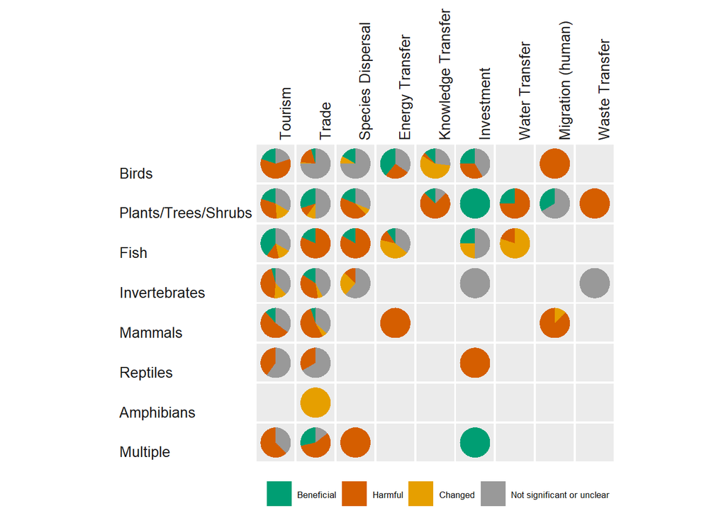

```r
# Matrix of pie charts
  sig_effect_cols <- sigeff_col

  metric_flow_fig <- ggplot(metric_flow) +
                    aes(x='', y = count, fill = sig_effect) +
                    geom_bar(position='fill',
                             stat='identity',
                             width = 1,
                             size = 0.01) +
                    # activate for vertical or horizontal version
                      facet_grid(taxa ~ tc, switch='y') + #horizontal
                      #facet_grid(tc ~ metric, switch='y') +  #vertical
                    # convert to pie chart
                      coord_polar(theta = 'y') +
                    # colors
                      scale_fill_manual(
                        values=sig_effect_cols,
                        guide = guide_legend(reverse = FALSE))  +
                        scale_y_discrete(position='right',expand=c(0,0))+
                    # style
                      theme_gray(base_size=8)+
                      theme(
                        axis.title=element_blank(),
                        axis.line=element_blank(),
                        axis.ticks=element_blank(),
                        axis.text=element_blank(),

                        legend.position = "bottom",
                        legend.justification='center',
                        legend.direction='horizontal',
                        legend.title = element_blank(),

                        panel.border = element_blank(),
                        panel.grid=element_blank(),
                        panel.grid.major = element_blank(),
                        panel.grid.minor = element_blank(),
                        plot.background = element_rect(),
                        plot.title=element_blank(),
                        strip.text.x = element_text(size=10,
                                          angle=90, vjust=0, hjust = 0),
                        strip.text.y.left = element_text(size=10,
                                          angle=0, vjust=0, hjust = 0),
                        strip.background = element_rect(fill='white'),
                        panel.spacing = unit(0.1, 'lines')
                        ) +
                    # labels
                      ylab('') + xlab('')



# display image
  metric_flow_fig
```

Flow Taxa Heatmap

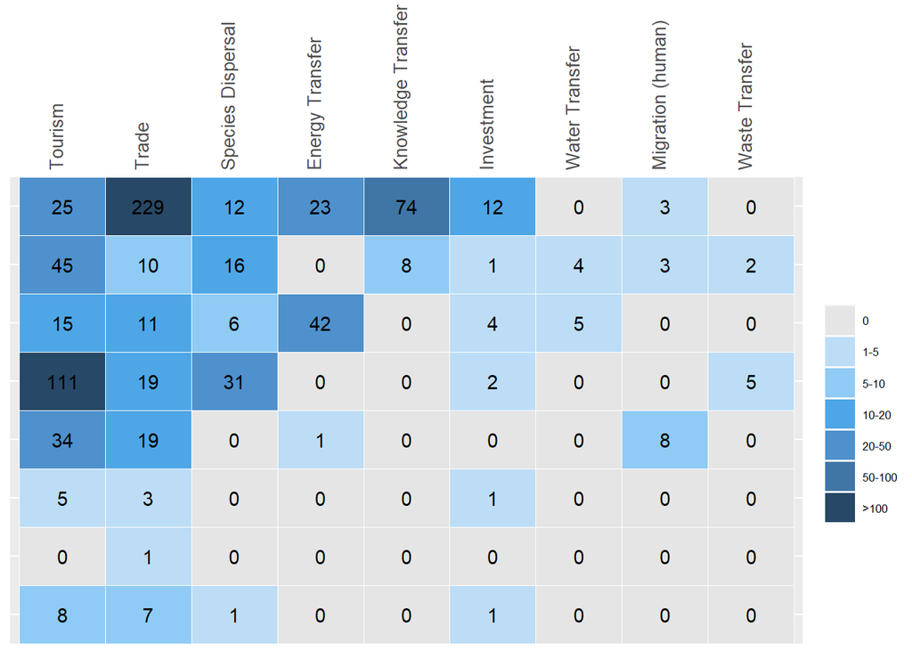

```r
# Load data of number of studies by taxa and flow
nr_metric_tele <- aggregate(x = metric_flow$count,
                               by = list(metric_flow$taxa, metric_flow$tc),
                               FUN = sum)



# Rename columns

names(nr_metric_tele)[1:3] <- c("taxa", "telecoupling", "count")

# Fill the gaps

mat_nr_metric_tele <-dcast(nr_metric_tele, taxa ~ telecoupling, value.var = 'count')
filled_nr_metric_tele <- melt(mat_nr_metric_tele, id=c("taxa"))
filled_nr_metric_tele[is.na(filled_nr_metric_tele)] <- 0
names(filled_nr_metric_tele)[2:3] <- c("telecoupling", "count")

# Create 'count' categories for representation

filled_nr_metric_tele$count_factor <- cut(filled_nr_metric_tele$count,
                                          breaks = c(-1,0,5,10,20,50,100,max(filled_nr_metric_tele$count,na.rm=T)),
                                          labels=c("0","1-5","5-10","10-20","20-50","50-100",">100"))


# Change order of factor levels for consistency with other figures
filled_nr_metric_tele$taxa <- factor(filled_nr_metric_tele$taxa, rev(taxa.sorted))

# Heatmap plot

heatmap_telemetric <- ggplot(filled_nr_metric_tele,
                      aes(x=telecoupling, y=taxa, fill=count_factor)) +
                      geom_tile(color = "white", size=0.25) +
                      geom_text(aes(label = count )) +
                      scale_fill_manual(values=c("grey90","#BCDDF5","#8FCBF5","#4EA6E6",
                                               "#4E91CC","#3F76A6","#274866"))+
                      labs(x="",y="")+
                      scale_y_discrete(expand=c(0,0))+
                      theme_grey(base_size=8)+

                      theme(legend.title = element_blank(),
                      # legend.text = element_blank(),
                      legend.position = "right",
                      plot.background=element_blank(),
                      plot.title = element_blank(),
                      axis.title= element_blank(),
                      axis.ticks = element_blank(),
                      axis.text.x.top = element_text(size=10, angle = 90, vjust=0,
                                                     hjust = 0),
                      axis.text.y.left = element_blank(),
                      strip.background = element_rect(fill="white"),
                      panel.spacing = unit(0.1, "lines")) +
                      scale_x_discrete(position = "top") +
                      labs(fill = "number of entries")

heatmap_telemetric
```

Side by side plot

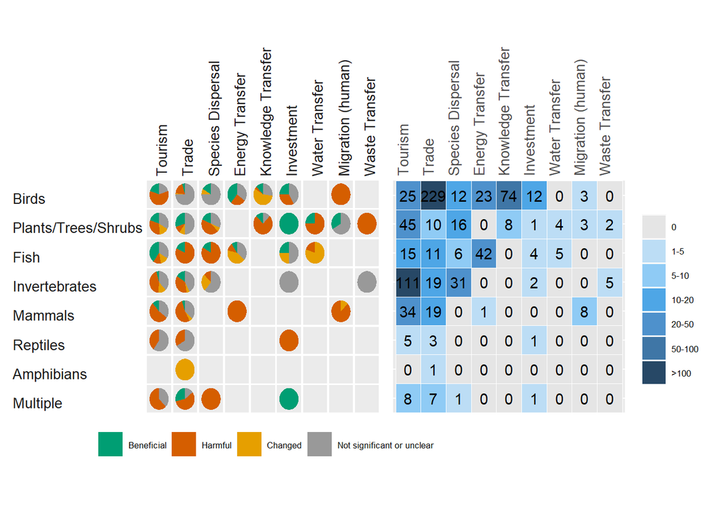

```r
# grid.arrange(metric_flow_fig, heatmap_telemetric, ncol=2)
k<-ggarrange(metric_flow_fig, heatmap_telemetric, ncol=2)
```

```r
#This actually save the plot in a image
    ggsave(file="figure2.svg", plot=k, width=10, height=8)
```

## Country/Region Entry Effects

```r
# Get continents, tc_cat, and maj_eff
ctr_tc_raw <- subset(taxEff_maj_rep, select = c('paper_id', 'bd_continents', 'tc', 'maj_eff_taxa'))
```

```r
# sig_effects level change
  ctr_tc_raw$maj_eff_taxa <- factor( ctr_tc_raw$maj_eff_taxa,
                             c( "Beneficial","Harmful","Changed","Mixed","Not significant or unclear"))
# telecoupling level change

  q <- table(ctr_tc_raw$tc)
  q <- q[order(-(q))]
  tc.sorted <- names(q)
  ctr_tc_raw$tc <- factor(  ctr_tc_raw$tc,tc.sorted)

# continent level change
  q <- table(ctr_tc_raw$bd_continents)
  q <- q[order(-(q))]
  cont.sorted <- names(q)
  ctr_tc_raw$bd_continents <- factor(  ctr_tc_raw$bd_continents,cont.sorted)
```

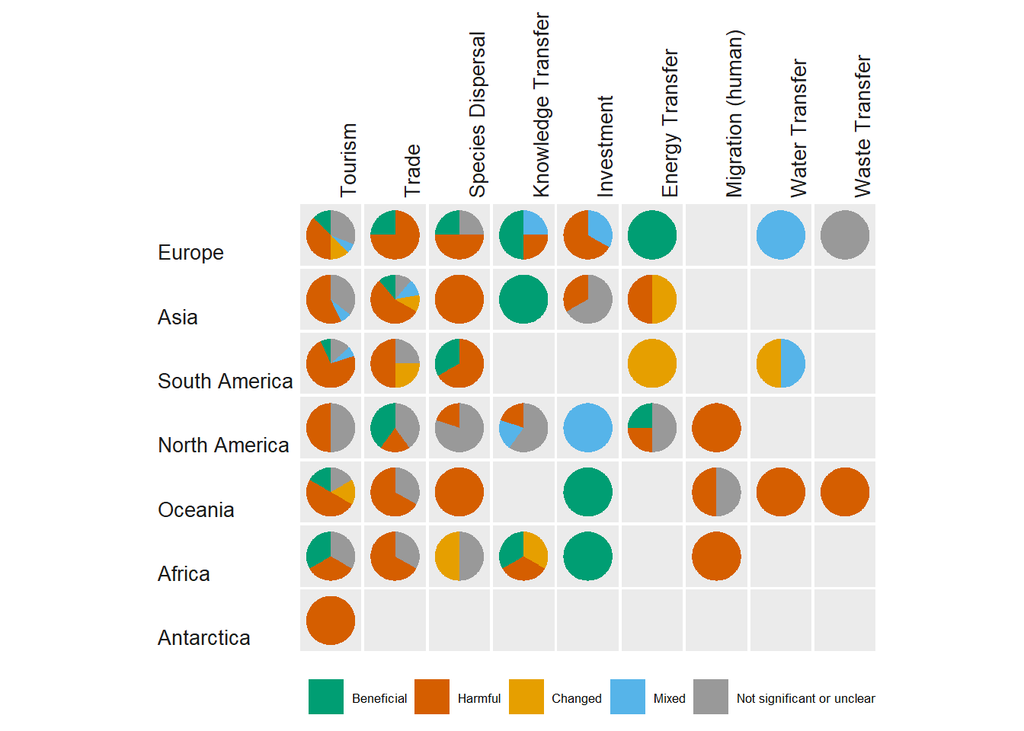

```r
ctr_tc_count <- ddply(ctr_tc_raw,
                       .(bd_continents, tc, maj_eff_taxa),
                       summarize,
                      # total count of entries
                        count=length(maj_eff_taxa))
cont_impact <- ddply(ctr_tc_raw,
                       .(bd_continents, maj_eff_taxa),
                       summarize,
                      # total count of entries
                        count=length(maj_eff_taxa)) %>%
                       group_by(bd_continents) %>%
                       nest() %>%
                        mutate(perc_per_taxa=map(data, function(x) x$count/sum(x$count))) %>%
                          unnest(cols = c(data, perc_per_taxa))

ctr_tc_fig <- ggplot(ctr_tc_count) +
                    aes(x='', y = count, fill = maj_eff_taxa) +
                    geom_bar(position='fill',
                             stat='identity',
                             width = 1,
                             size = 0.01) +
                    # activate for vertical or horizontal version
                      facet_grid(bd_continents ~ tc, switch='y') + #horizontal
                      #facet_grid(tc ~ metric, switch='y') +  #vertical
                    # convert to pie chart
                      coord_polar(theta = 'y') +
                    # colors
                      scale_fill_manual(
                        values=majeff_col,
                        guide = guide_legend(reverse = FALSE))  +
                        scale_y_discrete(position='right',expand=c(0,0))+
                    # style
                      theme_gray(base_size=8)+
                      theme(
                        axis.title=element_blank(),
                        axis.line=element_blank(),
                        axis.ticks=element_blank(),
                        axis.text=element_blank(),

                        legend.position = "bottom",
                        legend.justification='center',
                        legend.direction='horizontal',
                        legend.title = element_blank(),

                        panel.border = element_blank(),
                        panel.grid=element_blank(),
                        panel.grid.major = element_blank(),
                        panel.grid.minor = element_blank(),
                        plot.background = element_rect(),
                        plot.title=element_blank(),
                        strip.text.x = element_text(size=10,
                                          angle=90, vjust=0, hjust = 0),
                        strip.text.y.left = element_text(size=10,
                                          angle=0, vjust=0, hjust = 0),
                        strip.background = element_rect(fill='white'),
                        panel.spacing = unit(0.1, 'lines')
                        ) +
                    # labels
                      ylab('') + xlab('')



# display image
  ctr_tc_fig
```

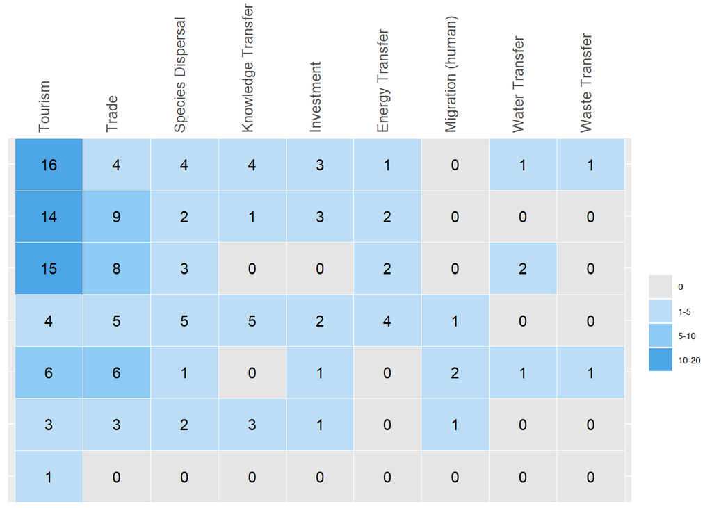

```
## [1] 153
```

```r
cont_freq <- as.data.frame(cbind(ctr_tc_count$bd_continents,ctr_tc_count$count))
cont_freq$V2<-as.numeric(cont_freq$V2)
sum(as.numeric(cont_freq$V2))

hi <-aggregate(x = cont_freq$V2, by = list(cont_freq$V1), FUN = sum)
hi <- hi[order(-hi$x),]
hi$perc <- hi$x / (sum(hi$x)) * 100


num_ctr_tele <- aggregate(x = ctr_tc_count$count,
                               by = list(ctr_tc_count$bd_continents, ctr_tc_count$tc),
                               FUN = sum)



names(num_ctr_tele)[1:3] <- c("continent", "telecoupling", "count")

num_ctr_tele$continent <- factor(num_ctr_tele$continent, rev(cont.sorted)                                       )


# Fill the gaps

mat_num_ctr_tele <-dcast(num_ctr_tele, continent ~ telecoupling, value.var = 'count')
filled_num_ctr_tele <- melt(mat_num_ctr_tele, id=c("continent"))
filled_num_ctr_tele[is.na(filled_num_ctr_tele)] <- 0
names(filled_num_ctr_tele)[2:3] <- c("telecoupling", "count")

# Create 'count' categories for representation

filled_num_ctr_tele$count_factor <- cut(filled_num_ctr_tele$count,
                                          breaks = c(-1,0,5,10,20,50,100,max(filled_num_ctr_tele$count,na.rm=T)),
                                          labels=c("0","1-5","5-10","10-20","20-50","50-100",">100"))


# Change order of factor levels for consistency with other figures

#filled_num_ctr_tele$continent <- factor(filled_num_ctr_tele$continent, c('South America','Oceania',
#'North America', 'Europe','Asia','Antarctica','Africa'))

# Heatmap plot

heatmap_tele_ctr <- ggplot(filled_num_ctr_tele,
                      aes(x=telecoupling, y=continent, fill=count_factor)) +
                      geom_tile(color = "white", size=0.25) +
                      geom_text(aes(label = count )) +
                      scale_fill_manual(values=c("grey90","#BCDDF5","#8FCBF5","#4EA6E6",
                                               "#4E91CC","#3F76A6","#274866"))+
                      labs(x="",y="")+
                      scale_y_discrete(expand=c(0,0))+
                      theme_grey(base_size=8)+

                      theme(legend.title = element_blank(),
                      # legend.text = element_blank(),
                      legend.position = "right",
                      plot.background=element_blank(),
                      plot.title = element_blank(),
                      axis.title= element_blank(),
                      axis.ticks = element_blank(),
                      axis.text.x.top = element_text(size=10, angle = 90, vjust=0,
                                                     hjust = 0),
                      axis.text.y.left = element_blank(),
                      strip.background = element_rect(fill="white"),
                      panel.spacing = unit(0.1, "lines")) +
                      scale_x_discrete(position = "top") +
                      labs(fill = "number of entries")

heatmap_tele_ctr
```

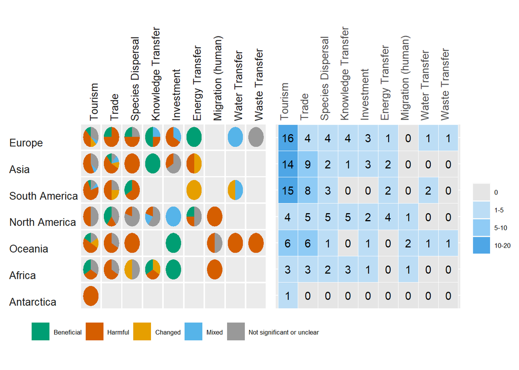

```r
k<-ggarrange(ctr_tc_fig, heatmap_tele_ctr, ncol=2)
```

```r
#This actually save the plot in a image
    ggsave(file="figure4.svg", plot=k, width=10, height=8)
```

Metric types

```r
# subset
  metrics2 <- subset(s23,
                    select=c('paper_id','entry_id','taxa',
                            'biodiv_cat_1sp',
                            'biodiv_cat_multsp',
                            'biodiv_cat_habitat'))
# melt
  metrics_long2 <- melt(metrics2, id.vars=c('paper_id','entry_id',
                            'taxa'))

# remove NA fields
  metrics_long2 <- metrics_long2[!is.na(metrics_long2$value),]

# change colnames
  colnames(metrics_long2)[4] <- 'metric_type'
  colnames(metrics_long2)[5] <- 'metric'

metrics_long2$metric_name <- paste0(metrics_long2$metric_type,'_', metrics_long2$metric)

metric_freq<-as.data.frame(table(metrics_long2$metric_name))
metric_freq <- metric_freq[order(-metric_freq$Freq),]
total_met <- nrow(s23)
metric_freq$perc <- (metric_freq$Freq/total_met)*100


table(s23$biodiv_cat_1sp)
abun <- s23[which(s23$biodiv_cat_1sp == 'Abundance/Density (number of individuals, individuals/unit area, biomass)'),]
occ <- s23[which(s23$biodiv_cat_1sp == 'Occurrence (presence, range, persistence, etc., NOT detection)'),]
```

```
##
## Abundance/Density (number of individuals, individuals/unit area, biomass)
##                                                                       188
##                                                                  Movement
##                                                                         5
##            Occurrence (presence, range, persistence, etc., NOT detection)
##                                                                       186
##    Population dynamics (survival, fitness, reproduction, mortality, etc.)
##                                                                         5
##        With-in species diversity (genetic diversity, age structure, etc.)
##                                                                        32
```

# Number check for Manuscript

## Abstract

### Percentage of impacts

Numbers with repeating tc, n=153

```r
nrow(taxEff_maj_rep)
table(taxEff_maj_rep$maj_eff_taxa)
prop.table(table(taxEff_maj_rep$maj_eff_taxa))
```

```
## [1] 153
##
##                 Beneficial                    Harmful
##                         19                         72
##                    Changed                      Mixed
##                         12                         11
## Not significant or unclear
##                         39
##
##                 Beneficial                    Harmful
##                 0.12418301                 0.47058824
##                    Changed                      Mixed
##                 0.07843137                 0.07189542
## Not significant or unclear
##                 0.25490196
```

Numbers with no repeating tc, n=136 USED FOR MS

```r
nrow(taxEff_maj)
table(taxEff_maj$maj_eff_taxa)
prop.table(table(taxEff_maj$maj_eff_tax))
```

```
## [1] 136
##
##                 Beneficial                    Harmful
##                         16                         67
##                    Changed                      Mixed
##                         11                          9
## Not significant or unclear
##                         33
##
##                 Beneficial                    Harmful
##                 0.11764706                 0.49264706
##                    Changed                      Mixed
##                 0.08088235                 0.06617647
## Not significant or unclear
##                 0.24264706
```

## Results

### Paragraph 1 - Impacts on Biodiversity, Metric-Level

Number of entries/metrics, n=767

```r
nrow(s23)
```

```
## [1] 767
```

Percentage impact type among metrics/entries

```r
table(s23$sig_effect)
prop.table(table(s23$sig_effect))
```

```
##
##                 Beneficial                    Changed
##                         82                        101
##                    Harmful Not significant or unclear
##                        225                        359
##
##                 Beneficial                    Changed
##                  0.1069100                  0.1316819
##                    Harmful Not significant or unclear
##                  0.2933507                  0.4680574
```

Freq of metric type

```r
metric_freq
```

|  | Var1 | Freq | perc |
| --- | --- | --- | --- |
| 1 | biodiv_cat_1sp_Abundance/Density (number of individuals, individuals/unit area, biomass) | 188 | 24.5110821 |
| 3 | biodiv_cat_1sp_Occurrence (presence, range, persistence, etc., NOT detection) | 186 | 24.2503259 |
| 8 | biodiv_cat_multsp_Abundance/Density (biomass, mass, number of individuals, individuals/unit area) | 110 | 14.3415906 |
| 14 | biodiv_cat_multsp_Richness (number of species) | 107 | 13.9504563 |
| 10 | biodiv_cat_multsp_Diversity index (Shannon-Weiner, Simpson's, Inverse Simpson's, etc.) | 54 | 7.0404172 |
| 9 | biodiv_cat_multsp_Composition (what species?) | 38 | 4.9543677 |
| 5 | biodiv_cat_1sp_With-in species diversity (genetic diversity, age structure, etc.) | 32 | 4.1720991 |
| 13 | biodiv_cat_multsp_Population dynamics (survival, fitness, reproduction, mortality, etc.) | 13 | 1.6949153 |
| 7 | biodiv_cat_habitat_Quality (pollution, connectence, disturbance, etc.) | 9 | 1.1734029 |
| 6 | biodiv_cat_habitat_Amount (e.g. land use change from non-habitat to habitat) | 8 | 1.0430248 |

[output cut: 4 more lines]

### Paragraph 2 - Multiple bd metrics

Percent of articles reporting mult bd metrics

```r
num.metric <- count(survey3$paper_id)
mult.metric <- num.metric[num.metric$freq > 1,]
nrow(mult.metric)/131
```

```
## [1] 0.7022901
```

Range of metric number

```r
range(num.metric$freq)
```

```
## [1]   1 162
```

### Paragraph 3 - Impacts on biodiversity, Study-Level

Percent impact of study level vs metric level

Table of study level

```r
prop.table(table(taxEff_maj$maj_eff_tax))
```

```
##
##                 Beneficial                    Harmful
##                 0.11764706                 0.49264706
##                    Changed                      Mixed
##                 0.08088235                 0.06617647
## Not significant or unclear
##                 0.24264706
```

Table of metric level

```r
prop.table(table(s23$sig_effect))
```

```
##
##                 Beneficial                    Changed
##                  0.1069100                  0.1316819
##                    Harmful Not significant or unclear
##                  0.2933507                  0.4680574
```

Percent impact at study level for taxa

```r
taxa.bar.data[which(taxa.bar.data$taxa == 'Mammals'),]
taxa.bar.data[which(taxa.bar.data$taxa == 'Birds'),]
taxa.bar.data[which(taxa.bar.data$taxa == 'Plants/Trees/Shrubs'),]
```

| taxa | maj_eff_taxa | count | perc_per_taxa |
| --- | --- | --- | --- |
| Mammals | Beneficial | 1 | 0.06666667 |
| Mammals | Harmful | 12 | 0.80000000 |
| Mammals | Not significant or unclear | 2 | 0.13333333 |

| taxa | maj_eff_taxa | count | perc_per_taxa |
| --- | --- | --- | --- |
| Birds | Beneficial | 7 | 0.18918919 |
| Birds | Harmful | 16 | 0.43243243 |
| Birds | Changed | 2 | 0.05405405 |
| Birds | Mixed | 4 | 0.10810811 |
| Birds | Not significant or unclear | 8 | 0.21621622 |

| taxa | maj_eff_taxa | count | perc_per_taxa |
| --- | --- | --- | --- |
| Plants/Trees/Shrubs | Beneficial | 5 | 0.16666667 |
| Plants/Trees/Shrubs | Harmful | 13 | 0.43333333 |
| Plants/Trees/Shrubs | Changed | 3 | 0.10000000 |
| Plants/Trees/Shrubs | Mixed | 2 | 0.06666667 |
| Plants/Trees/Shrubs | Not significant or unclear | 7 | 0.23333333 |

### Paragraph 4 - Percent impact at study level for flow

Impact percentages by flow

```r
flow_bar_data[which(flow_bar_data$tc == 'Tourism'),]
flow_bar_data[which(flow_bar_data$tc == 'Trade'),]
flow_bar_data[which(flow_bar_data$tc == 'Species Dispersal'),]
flow_bar_data[which(flow_bar_data$tc == 'Investment'),]
flow_bar_data[which(flow_bar_data$tc == 'Knowledge Transfer'),]
flow_bar_data[which(flow_bar_data$tc == 'Water Transfer'),]
flow_bar_data[which(flow_bar_data$tc == 'Energy Transfer'),]
```

| tc | maj_eff_taxa | count | perc_per_tc |
| --- | --- | --- | --- |
| Tourism | Beneficial | 5 | 0.08474576 |
| Tourism | Harmful | 32 | 0.54237288 |
| Tourism | Changed | 3 | 0.05084746 |
| Tourism | Mixed | 3 | 0.05084746 |
| Tourism | Not significant or unclear | 16 | 0.27118644 |

| tc | maj_eff_taxa | count | perc_per_tc |
| --- | --- | --- | --- |
| Trade | Beneficial | 4 | 0.11428571 |
| Trade | Harmful | 19 | 0.54285714 |
| Trade | Changed | 3 | 0.08571429 |
| Trade | Mixed | 1 | 0.02857143 |
| Trade | Not significant or unclear | 8 | 0.22857143 |

| tc | maj_eff_taxa | count | perc_per_tc |
| --- | --- | --- | --- |
| Species Dispersal | Beneficial | 2 | 0.11764706 |
| Species Dispersal | Harmful | 8 | 0.47058824 |
| Species Dispersal | Changed | 1 | 0.05882353 |
| Species Dispersal | Not significant or unclear | 6 | 0.35294118 |

| tc | maj_eff_taxa | count | perc_per_tc |
| --- | --- | --- | --- |
| Investment | Beneficial | 2 | 0.2 |
| Investment | Harmful | 3 | 0.3 |
| Investment | Mixed | 3 | 0.3 |
| Investment | Not significant or unclear | 2 | 0.2 |

| tc | maj_eff_taxa | count | perc_per_tc |
| --- | --- | --- | --- |
| Knowledge Transfer | Beneficial | 4 | 0.30769231 |
| Knowledge Transfer | Harmful | 3 | 0.23076923 |
| Knowledge Transfer | Changed | 1 | 0.07692308 |
| Knowledge Transfer | Mixed | 2 | 0.15384615 |
| Knowledge Transfer | Not significant or unclear | 3 | 0.23076923 |

| tc | maj_eff_taxa | count | perc_per_tc |
| --- | --- | --- | --- |
| Water Transfer | Harmful | 1 | 0.25 |
| Water Transfer | Changed | 1 | 0.25 |
| Water Transfer | Mixed | 2 | 0.50 |

| tc | maj_eff_taxa | count | perc_per_tc |
| --- | --- | --- | --- |
| Energy Transfer | Beneficial | 2 | 0.2222222 |
| Energy Transfer | Harmful | 2 | 0.2222222 |
| Energy Transfer | Changed | 3 | 0.3333333 |
| Energy Transfer | Not significant or unclear | 2 | 0.2222222 |

### Paragraph 5 - Percent impact by region

Frequency of Regions, tc repeated (USE ctr_tc_count for tc specific numbers)

```r
prop.table(table(ctr_tc_raw$bd_continents))
```

```
##
##        Europe          Asia South America North America       Oceania
##   0.222222222   0.202614379   0.196078431   0.169934641   0.117647059
##        Africa    Antarctica
##   0.084967320   0.006535948
```

Impact percent for Regions, tc repeated (USE ctr_tc_count for tc specific numbers)

```r
cont_impact[which(cont_impact$bd_continents == 'Europe'),]
cont_impact[which(cont_impact$bd_continents == 'Asia'),]
cont_impact[which(cont_impact$bd_continents == 'South America'),]
cont_impact[which(cont_impact$bd_continents == 'North America'),]
cont_impact[which(cont_impact$bd_continents == 'Oceania'),]
cont_impact[which(cont_impact$bd_continents == 'Africa'),]
cont_impact[which(cont_impact$bd_continents == 'Antarctica'),]
```

| bd_continents | maj_eff_taxa | count | perc_per_taxa |
| --- | --- | --- | --- |
| Europe | Beneficial | 7 | 0.20588235 |
| Europe | Harmful | 14 | 0.41176471 |
| Europe | Changed | 2 | 0.05882353 |
| Europe | Mixed | 4 | 0.11764706 |
| Europe | Not significant or unclear | 7 | 0.20588235 |

| bd_continents | maj_eff_taxa | count | perc_per_taxa |
| --- | --- | --- | --- |
| Asia | Beneficial | 2 | 0.06451613 |
| Asia | Harmful | 17 | 0.54838710 |
| Asia | Changed | 2 | 0.06451613 |
| Asia | Mixed | 2 | 0.06451613 |
| Asia | Not significant or unclear | 8 | 0.25806452 |

| bd_continents | maj_eff_taxa | count | perc_per_taxa |
| --- | --- | --- | --- |
| South America | Beneficial | 2 | 0.06666667 |
| South America | Harmful | 17 | 0.56666667 |
| South America | Changed | 5 | 0.16666667 |
| South America | Mixed | 2 | 0.06666667 |
| South America | Not significant or unclear | 4 | 0.13333333 |

| bd_continents | maj_eff_taxa | count | perc_per_taxa |
| --- | --- | --- | --- |
| North America | Beneficial | 3 | 0.1153846 |
| North America | Harmful | 7 | 0.2692308 |
| North America | Mixed | 3 | 0.1153846 |
| North America | Not significant or unclear | 13 | 0.5000000 |

| bd_continents | maj_eff_taxa | count | perc_per_taxa |
| --- | --- | --- | --- |
| Oceania | Beneficial | 2 | 0.11111111 |
| Oceania | Harmful | 11 | 0.61111111 |
| Oceania | Changed | 1 | 0.05555556 |
| Oceania | Not significant or unclear | 4 | 0.22222222 |

| bd_continents | maj_eff_taxa | count | perc_per_taxa |
| --- | --- | --- | --- |
| Africa | Beneficial | 3 | 0.2307692 |
| Africa | Harmful | 5 | 0.3846154 |
| Africa | Changed | 2 | 0.1538462 |
| Africa | Not significant or unclear | 3 | 0.2307692 |

| bd_continents | maj_eff_taxa | count | perc_per_taxa |
| --- | --- | --- | --- |
| Antarctica | Harmful | 1 | 1 |

### Paragraph 6 - Search result

Number of articles from search

```r
nrow(ab_all)
```

```
## [1] 7306
```

Number of articles in sample

```r
nrow(s2)
```

```
## [1] 131
```

### Paragraph 7 - Flow freq in sample

Number of articles in sample

```r
nrow(s2)
```

```
## [1] 131
```

Flow frequency

```r
tc.count
```

|  | tc.list | tc.count | perc |
| --- | --- | --- | --- |
| 6 |  |  | 43.511450 |
| 7 |  |  | 25.954198 |
| 5 |  |  | 12.977099 |
| 3 |  |  | 9.923664 |
| 1 |  |  | 6.870229 |
| 2 |  |  | 6.106870 |
| 4 |  |  | 3.053435 |
| 9 |  |  | 3.053435 |
| 8 |  |  | 1.526718 |

Percentage of multiple tc

```r
multiple/nrow(s2)
```

```
##      TRUE
## 0.1221374
```

### Paragraph 8 - Habitat and taxa freq in sample

Habitat freq

```r
prop.table(table(s23_maj$hab))
```

```
##
##                 Freshwater          Freshwater;Marine
##                0.167938931                0.007633588
##                     Marine Not specified/Global study
##                0.190839695                0.015267176
##                Terrestrial     Terrestrial;Freshwater
##                0.572519084                0.030534351
##         Terrestrial;Marine
##                0.015267176
```

Taxa freq

```r
taxa.count
```

|  | taxa.list | taxa.count | perc |
| --- | --- | --- | --- |
| 5 |  |  | 28.2442748 |
| 2 |  |  | 22.9007634 |
| 7 |  |  | 22.1374046 |
| 1 |  |  | 11.4503817 |
| 6 |  |  | 11.4503817 |
| 8 |  |  | 3.8167939 |
| 3 |  |  | 3.0534351 |
| 4 |  |  | 0.7633588 |

### Paragraph 9 - Region freq in sample

Table of country freq

```r
ctr_bio
```

| biodiv_countries | n | continent | ctr_name |
| --- | --- | --- | --- |
| BRA | 19 | South America | Brazil, Federative Republic of |
| USA | 13 | North America | United States of America |
| CHN | 10 | Asia | China, People's Republic of |
| AUS | 8 | Oceania | Australia, Commonwealth of |
| ESP | 8 | Europe | Spain, Kingdom of |
| ITA | 7 | Europe | Italy, Italian Republic |
| FRA | 6 | Europe | France, French Republic |
| DEU | 5 | Europe | Germany, Federal Republic of |
| IND | 5 | Asia | India, Republic of |
| ZAF | 5 | Africa | South Africa, Republic of |

[output cut: 64 more lines]

Table of continent freq, n=131

```r
cont.count
```

|  | cont.list | cont.count | perc |
| --- | --- | --- | --- |
| 4 |  |  | 22.9007634 |
| 2 |  |  | 19.8473282 |
| 6 |  |  | 19.0839695 |
| 1 |  |  | 16.7938931 |
| 5 |  |  | 12.9770992 |
| 3 |  |  | 7.6335878 |
| 7 |  |  | 0.7633588 |